# Week 4

Introduction to Data Science in Health and Social Care HEIN11037

Dr Brittany Blankinship

# Week 4 Tutorial

Introduction to Data Science in Health and Social Care HEIN11037

## Agenda

- Course updates
- Datathon project assessments outline + Q&A
- Data storytelling
- More on R and Quarto

## How are you feeling today?

On this animal scale

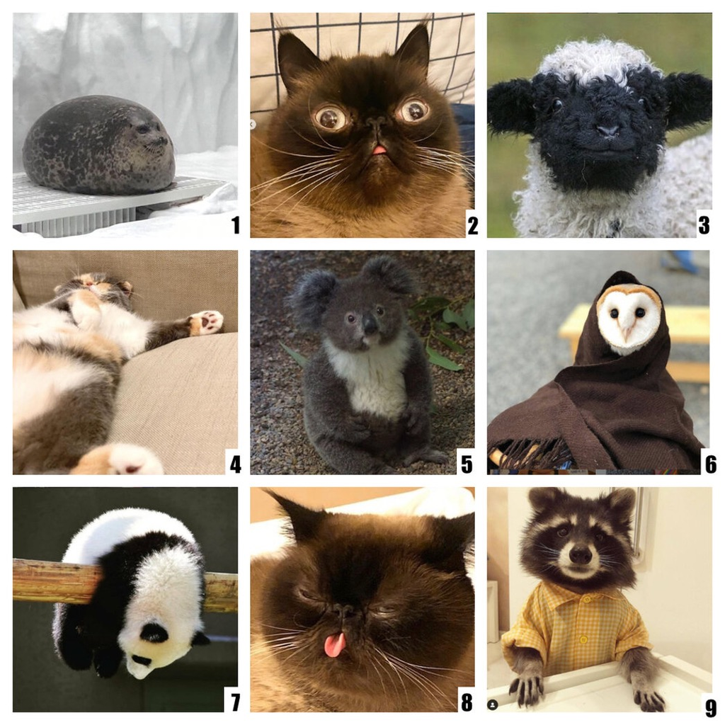

## Look out for messages from your Student Representatives

🤩 Burcu Çapraz Yavuz

🤩 Michaela Kapnias

🤩 Nathan Jjombwe

🤩 Teboho Pelesa

## Cohort GitHub Repository

> Any suggestions for names?

This repo will follow your cohort throughout your studies on the program & be used in upcoming Git + GitHub content

`2026-intake` is a boring repo name

# Have you read the assessment handbook?

# Datathon Project

## Datathon components

2 assessed aspects

## Datathon projects

Create a **data story** using OECD Health Data

- Entirely up to you to decide on your data story
  - Specific variables & covariates (dates, countries, demographics, etc.) are entirely up to you!
- You are invited to use other datasets, but must use some data from the [health care utilisation dataset](https://data-explorer.oecd.org/vis?df%5Bds%5D=DisseminateFinalDMZ&df%5Bid%5D=DSD_HEALTH_PROC%40DF_KEY_INDIC&df%5Bag%5D=OECD.ELS.HD&dq=.................&pd=,&to%5BTIME_PERIOD%5D=false&vw=ov)

## Datathon projects

⚠️ Use of Generative AI tools **must be declared**

- See Assessment Handbook Section 8 for details
- Declaration in submission coversheet does not count towards word count

⚠️ Must use the unfiltered healthcare use dataset (RData file)

- 610,881 data points/rows

## Report

> Due: 14 December 2026, 2 pm GMT

1500 word Quarto report

⚖️ Evaulated on 4 aspects:

1. Narrative and effective data storytelling (30%)
2. Critical thinking (30%)
3. Data wrangling and coding (20%)
4. Data visualisation (20%)

## Report

> Due: 14 December 2026, 2 pm GMT
- Be sure to show code chunks with default `echo: true`
- Code does not count towards the 1,500 word limit
- Only need to show the code that you used to read in the data, wrangle it, and create your data visualisations
  - not all of the code you have written across the project
- 📬 Submit: HTML or PDF rendered file type, the QMD file, & completed submission declaration

## Recorded Presentation

> Due: 4 January 2027, 2 pm GMT
- **5 minute** presentation with up to **8 content slides** (not including title slide)
  - It is recorded, so you can practice and submit your best take!
- 2 key data visualisations
- Presentation made with Quarto slides (we will learn more how to do this in Week 7)
- **Must select a new audience from your report and update your data story accordingly**
  - As such, will submit a 300-word justification of the data visualisation used in your presentation

## Recorded Presentation

> Due: 4 January 2027, 2 pm GMT

⚖️ Evaulated on 4 aspects:

1. Narrative and effective storytelling (30%)
2. Data visualisation (30%)
3. Professionalism and slides (10%)
4. Data visualization rationale (30%)

📬 Submit:

1. completed submisson declaration
2. the video of your presentation
3. the slides HTML file
4. the code (.QMD file) used to produce the slides and visuals used in your presentation
5. PNGs of the visuals used in your report
6. 300-word justification presentation data visualisations

## OECD Data Explorer Portal

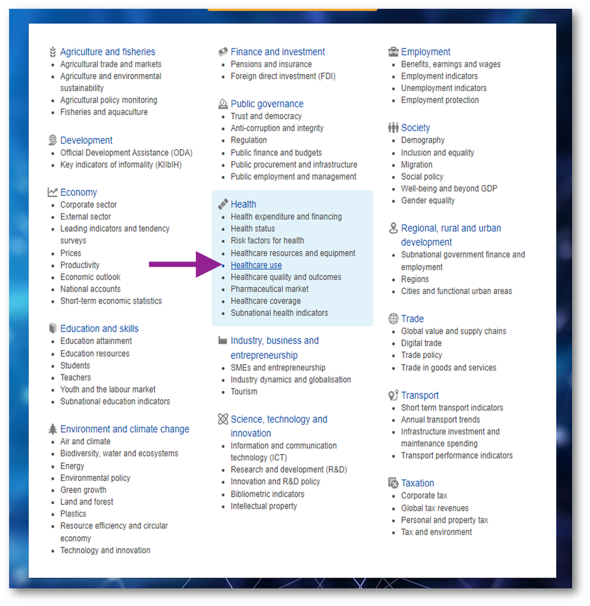

OECD Data Explorer Tool: Themes

For further guidance on how to access the data, on the Learn pages go to Assessment > Assessment Criteria and Submission Details.

- RData File provided with unfiltered Healthcare Use dataset that must be used in your assignments.

## Formative Discussion Post

- **Available**: Next week on Monday (19 October 2026)
  - Post by Week 9 to receive formative feedback
- **Topic**: Datathon project data and context
- Can view other posts after submitting yours – respond to your classmates!
- A member of the teaching team will give you feedback

## Optional Datathon Peer Support Groups

Self-enrol group on Learn which will open a discussion board:

- where students interested in the same theme within the data can work together and discuss their projects

[figure not shown]

9 themes/groupings of data

# Data Storytelling

## Data Storytelling

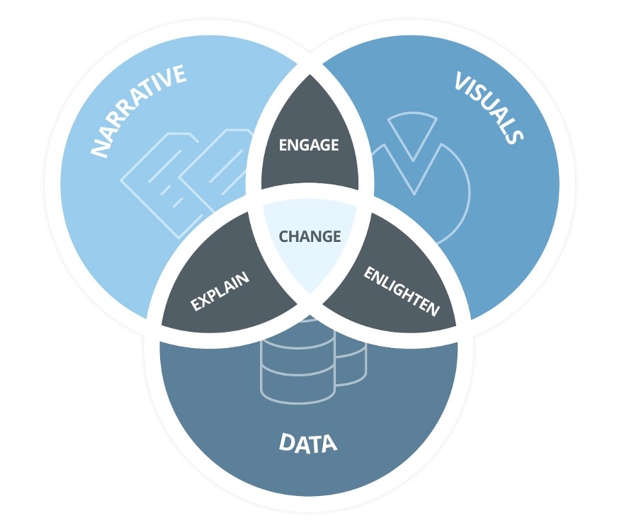

## Data Storytelling

[figure not shown]

## 🥪 Data Story vs 🍕 Story with Data

- Datathon = 🥪 **data story – the foundation is data & data is revealing the story**
- The narrative explains and contextualizes the data, making the findings accessible, understandable & engaging
- Data stories are about inspiring change & clear, data-driven calls to action
- You can read more about this distinction on [Brent Dykes effectivestorytelling blog](https://www.effectivedatastorytelling.com/post/data-stories-vs-stories-with-data-whats-the-difference)

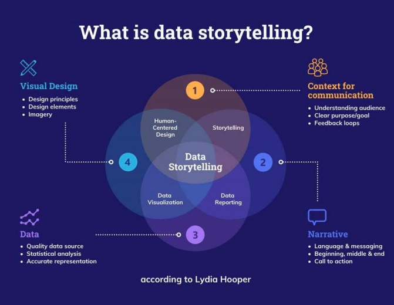

You can read [Lydia Hooper’s blog here](https://venngage.com/blog/data-storytelling/).

Note that data storytelling and stories with data are used interchangeably in the blog post, but what is discussed is what we are calling data stories.

## Things to consider *before* narrative and visualisations

- Who is your audience?
- What do you need your audience to know or do?
- How will you communicate to your audience? (e.g., written report, presentation)
- 🥪 Data drives the story. You are not looking for data to support a narrative you have already decided on

## Storyboarding can help!

- **Do not start with presentation software** when creating a data story
  - your presentation is a final product - not a work in progress
- **Storyboard** can be used to establish a structure & flow for your narrative
  - a **visual outline** of the content you plan to develop
  - particularly useful when working in online &/or in teams

## Storyboarding

- Whiteboard
- Post-it notes
- Software such as Padlet or Trello

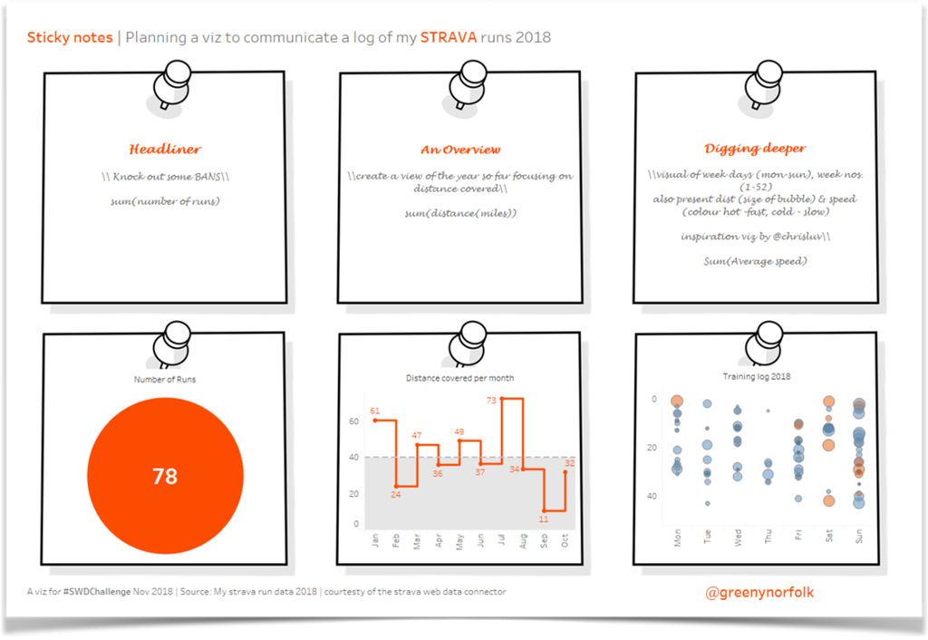

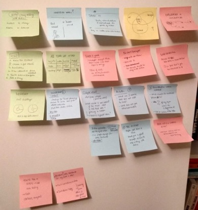

## Storytelling techniques

1. **Lead statement**
- Complete sentence
- Conveys the problem and articulates key insight
2. **Elevator pitch**
- Short statements encapsulating your data story which captures your audience’s attention and sparks interest
- 5 steps
  - Understand your objective
  - Understand your audience
  - Outline the problem
  - Outline the solution
  - Call to action

## 🗝️ Key features of a good pitch:

- Credible (no overblown claims)
- Customised to your audience
  - you’ll rarely give a pitch to the same audience twice
- Conversational for non-expert audience (avoid jargon)
- Clear
- Concise

## 💡💡 Pitch top tips 💡💡

- Content, structure, delivery: all **equally** important
- Attention-grabbing start and solid conclusion
- Audience – language
- Have some notes, but don’t read from a script
- Thinking pauses. You need to breathe. The audience needs to think about what you are saying (we speak 135-150 words/minute at a natural pace).
- Use your own voice. Helps with credibility

# Any questions?

## Coding Time 🚀

1. Navigate to the **Tutorial/Live Session Material** on Learn
2. Download the **Week 4 Tutorial Resources** (.qmd file and image)
3. Open the qmd file in an **R Project**